# Ginty lab Neuron RNA-Seq II

Meeta Mistry

08/31/2015

RNA-Seq analysis for Yang Zheng (zylittlep@gmail.com) at Neurobiology. Contact Meeta Mistry (mmistry@hsph.harvard.edu) for additional details. Request from client was:

> We consulted with the bioinformatics core for RNA-seq analysis a while ago. I just got my new RNA-seq data and I’m wondering whether we can re-open the consult and add these samples in for analysis. Additional samples include:
> - Abeta-RA-LTMR:NPY2R150407, NPY2R150516, NPY2R750820
> - Abeta-SA1-LTMR: SA1-2, SA1-04080419, SA1-04200521

## Workflow:

- run fastq files through [bcbio](https://bcbio-nextgen.readthedocs.org/en/latest/index.html)
- assess QC
- Correlation structure / clustering
- SA1 versus Npy2r comparison

## Setup

### Bioconductor and R libraries used

```r
loadlibs <- function(){
library(ggplot2)
library(reshape)
library(gplots)
library(DESeq2)
library(CHBUtils)
library(Biobase)
library(RColorBrewer)
library(pheatmap)
library(gProfileR)
source('revigo.R') ## for GO analysis
}
suppressPackageStartupMessages(loadlibs())
```

### Get variables

- get base directory for analyses
- specify data and results directories
- specify column headers used in metadata file

```r
baseDir=getwd()
dataDir=paste(baseDir, "/data", sep="")
resultsDir=paste(baseDir, "/results", sep="")
metaDir=paste(baseDir, "/meta", sep="")

heatcolors.1 <- rev(brewer.pal(6, "YlOrRd"))
heatcolors.2 <- colorRampPalette(brewer.pal(9, "GnBu"))(100)
cbPalette <- cbPalette <- c("#999999", "#E69F00", "#56B4E9", "#009E73", "#F0E442", "#0072B2",
                            "#D55E00", "#CC79A7", "#000000")
```

## Load data

```r
# Load data
counts <- read.delim(file.path(dataDir, 'combined.counts'), sep="\t", row.names=1, header=T)
cols <-  sapply(colnames(counts), function(x){gsub(".counts", "", x)}, USE.NAMES=F)
colnames(counts) <- cols
ann.counts <- read.delim(file.path(dataDir, 'annotated_combined.counts'), sep="\t", row.names=1, header=T)

# Load metadata
meta <- read.csv(file.path(metaDir, 'ginty_neuron_2.csv'), row.names=1)
rows <- sapply(rownames(meta), function(x){gsub(".fastq.gz", "", x)}, USE.NAMES=F)
row.names(meta) <- rows

# Create eset
eset <- new("ExpressionSet", exprs=as.matrix(counts))
pData(eset) <- meta
fData(eset) <- data.frame(GeneSymbol=ann.counts[,'symbol'], row.names=row.names(ann.counts))
```

## Correlation Plots and PCA

Seems like the samples tend to segregate by neurontype.

```r
# Create DESeq2 dataset
dds <- DESeqDataSetFromMatrix(countData = exprs(eset), colData = pData(eset), design = ~ neurontype )
dds <- DESeq(dds)
```

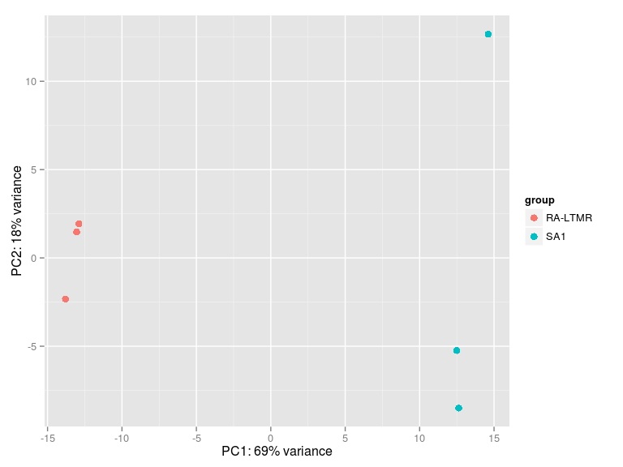

```r
# Visualizing counts transformed by rlog transformation (unbiased)
norm_rld <- rlog(dds, blind=TRUE)

# Plot PCA
print(plotPCA(norm_rld, intgroup=c("neurontype")))
```

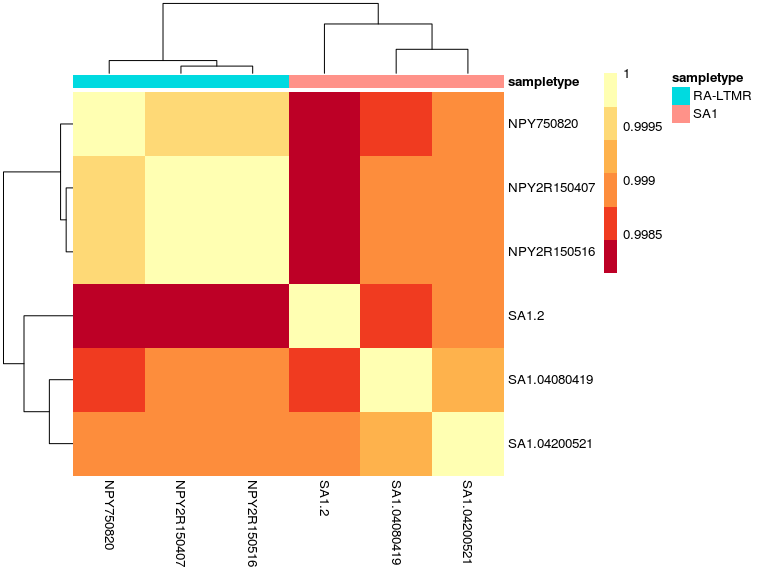

```r
# Plot correlation
norm_rld <- assay(norm_rld)
annotation <- data.frame(sampletype=meta[,'neurontype'], row.names=row.names(meta))

pheatmap(cor(norm_rld), color = heatcolors.1, cluster_rows = T,
         annotation=annotation, border_color=NA,
         cluster_cols = T, show_colnames = T, clustering_distance_rows = "euclidean",
         clustering_distance_cols = "euclidean",
         fontsize = 10, fontsize_row = 10, height=20)
```

## Differentially expressed genes

Using DESeq to evaluate differential expression between SA1 and Npy2r neuron subtypes, we get a **total of 163 genes identifed as significant.** This based on a somewhat stringent threshold of **p-adjusted < 0.05 and abs(log2FoldChange) > 2.0.** In the volcano plot depicted below, each of the genes are plotted with adusted p-value on the y-axis and log2FC on the x-axis. Purple points indicate those that meet significance criteria specified above.

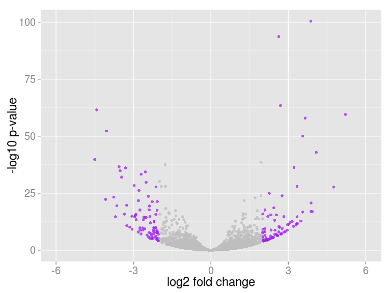

```r
# Extract contrasts
contrast <- list("neurontypeRA.LTMR" , "neurontypeSA1")
res <- results(dds, contrast=contrast)

# Set cutoffs
padj.cutoff <- 0.05
fc.cutoff <- 2

# Identify significant genes
res$threshold <- as.logical(res$padj < padj.cutoff & abs(res$log2FoldChange) > fc.cutoff)

# Volcano plots to visualize significant genes
df <- data.frame(res)
ggplot(data=df, aes(x=log2FoldChange, y=-log10(padj), colour=threshold)) +
  scale_color_manual(values = c("grey", "purple")) +
  xlim(c(-6,6)) +
  geom_point(alpha=0.75, pch=16) +
  theme(legend.position = "none",
        plot.title = element_text(size = rel(1.5)),
        axis.title = element_text(size = rel(1.5)),
        axis.text = element_text(size = rel(1.25))) +
  xlab("log2 fold change") + ylab("-log10 p-value")
```

## Functional Analysis

We used the 163 genes as input to [gProfileR](http://biit.cs.ut.ee/gprofiler/), a tool that performs statistical enrichment analysis to find over-representation of information like Gene Ontology terms, biological pathways, regulatory DNA elements, human disease gene annotations, and protein-protein interaction networks. From the gprofiler results the significant Gene Ontolgy terms were extracted and some of the top terms are highlighted in the table below. The full results table containing all annotation terms can be found in the Files for Download section.

```r
### Get gene names for only significant genes
sig <- row.names(res)[which(res$threshold)]
sig <- unique(sig)

### Functional analysis using gProfiler
gprofiler_results  <-   gprofiler(query = sig,
                                  organism = "mmusculus",
                                  ordered_query = F,
                                  exclude_iea = F,
                                  max_p_value = 0.05,
                                  max_set_size = 0,
                                  correction_method = "fdr",
                                  hier_filtering = "none",
                                  domain_size = "annotated",
                                  custom_bg = "")

allterms <- gprofiler_results$term.id
go_table <- gprofiler_results[grep('GO:', allterms) ,
                              c("term.id", "term.name", "p.value", "overlap.size", "precision","recall")]
kable(head(go_table[order(go_table$p.value),], 10), format='markdown', row.names=F)
```

| term.id | term.name | p.value | overlap.size | precision | recall |
| --- | --- | --- | --- | --- | --- |
| GO:0007267 | cell-cell signaling | 0e+00 | 26 | 0.029 | 0.161 |
| GO:0007268 | synaptic transmission | 0e+00 | 20 | 0.038 | 0.124 |
| GO:0036477 | somatodendritic compartment | 0e+00 | 24 | 0.030 | 0.149 |
| GO:0043005 | neuron projection | 0e+00 | 27 | 0.026 | 0.168 |
| GO:0097458 | neuron part | 0e+00 | 30 | 0.023 | 0.186 |
| GO:0030425 | dendrite | 1e-07 | 18 | 0.035 | 0.112 |
| GO:0046903 | secretion | 2e-07 | 24 | 0.025 | 0.149 |
| GO:0065008 | regulation of biological quality | 3e-07 | 45 | 0.015 | 0.280 |
| GO:0043025 | neuronal cell body | 3e-07 | 18 | 0.032 | 0.112 |
| GO:0044297 | cell body | 3e-07 | 19 | 0.030 | 0.118 |

The significant GO terms from gProfiler were used as input to [REVIGO](http://revigo.irb.hr/) to visualize the most prominent processes and reduce redundancy of terms. Each rectangle is a single cluster representative, where terms sharing parent term at some level have been grouped together. The representatives are joined into ‘superclusters’ of loosely related terms, visualized with different colors. Size of the text reflect either the p-value, or the frequency of the GO term in the underlying GOA database.

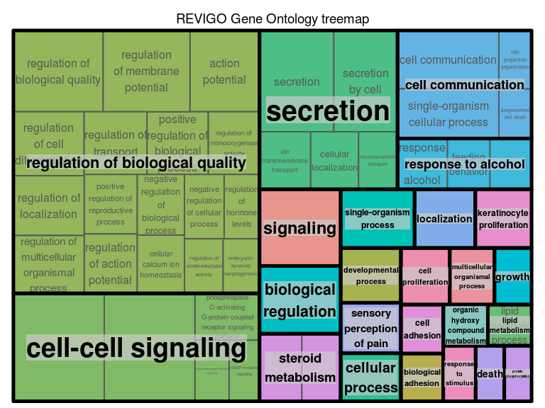

## Files for download

- Full count data matrix
- Full FPKM matrix
- Full results table from DESeq2
- FPKM matrix for significant genes
- gProfiler results